# MD06 Demo 2

For this demo we’re going to need some data from the **bayesrules** package. So be sure to install that.

```r
library(moderndive)
library(tidyverse)
theme_set(theme_light())
```

Load the data and take a look. This is data from a DC Rideshare service. The main outcome here is `rides` – the number of rides on that day.

```r
data(bikes, package = "bayesrules")
glimpse(bikes)
```

```
Rows: 500
Columns: 13
$ date        <date> 2011-01-01, 2011-01-03, 2011-01-04, 2011-01-05, 2011-01-0…
$ season      <fct> winter, winter, winter, winter, winter, winter, winter, wi…
$ year        <int> 2011, 2011, 2011, 2011, 2011, 2011, 2011, 2011, 2011, 2011…
$ month       <fct> Jan, Jan, Jan, Jan, Jan, Jan, Jan, Jan, Jan, Jan, Jan, Jan…
$ day_of_week <fct> Sat, Mon, Tue, Wed, Fri, Sat, Mon, Tue, Wed, Thu, Fri, Sat…
$ weekend     <lgl> TRUE, FALSE, FALSE, FALSE, FALSE, TRUE, FALSE, FALSE, FALS…
$ holiday     <fct> no, no, no, no, no, no, no, no, no, no, no, no, no, yes, n…
$ temp_actual <dbl> 57.39952, 46.49166, 46.76000, 48.74943, 46.50332, 44.17700…
$ temp_feel   <dbl> 64.72625, 49.04645, 51.09098, 52.63430, 50.79551, 46.60286…
$ humidity    <dbl> 80.5833, 43.7273, 59.0435, 43.6957, 49.8696, 53.5833, 48.2…
$ windspeed   <dbl> 10.749882, 16.636703, 10.739832, 12.522300, 11.304642, 17.…
$ weather_cat <fct> categ2, categ1, categ1, categ1, categ2, categ2, categ1, ca…
$ rides       <int> 654, 1229, 1454, 1518, 1362, 891, 1280, 1220, 1137, 1368, …
```

Here’s an overview of the big trends in the data.

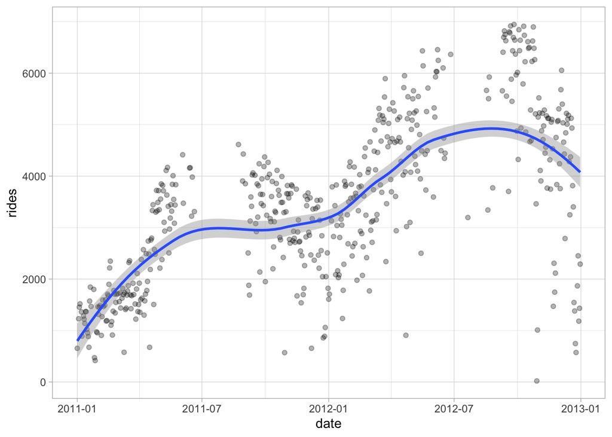

```r
ggplot(bikes,
       aes(x = date,
           y = rides)) +
  geom_point(alpha = .3) +
  geom_smooth(method = "loess")
```

## Simple regression

Let’s try a simple regression: the number of rides as a function of temperature.

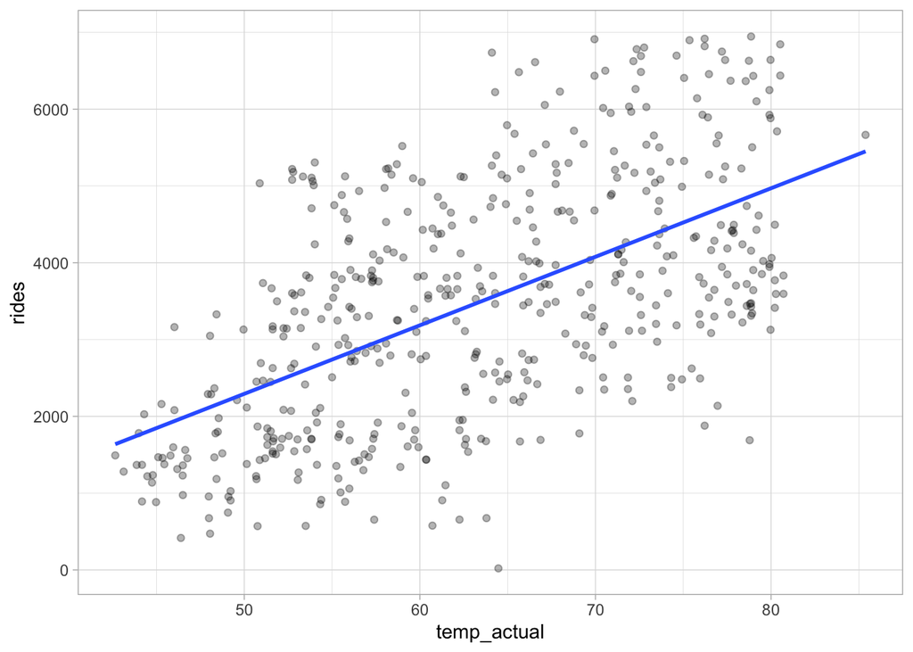

```r
ggplot(bikes,
       aes(x = temp_actual,
           y = rides)) +
  geom_jitter(alpha = .3) +
  geom_smooth(method = "lm",
              se = FALSE)
```

Let’s look at the coefficients from such a model.

```r
model1 <- lm(rides ~ temp_actual,
             data = bikes)
get_regression_table(model1) |>
  select(term, estimate)
```

```
# A tibble: 2 × 2
  term        estimate
  <chr>          <dbl>
1 intercept    -2169.
2 temp_actual     89.2
```

Here’s the result in equation form:

$$\widehat{rides_i} = -2169 + 89.2 \times Fahrenheit_i$$

What do these numbers mean?

- -2169 is the expected number of rides when the temperature = 0 degrees (Fahrenheit).
- for every degree (Fahrenheit) the temperature goes up, we expect there to be 89.2 additional riders.

To understand the intercept better, let’s look at it this way:

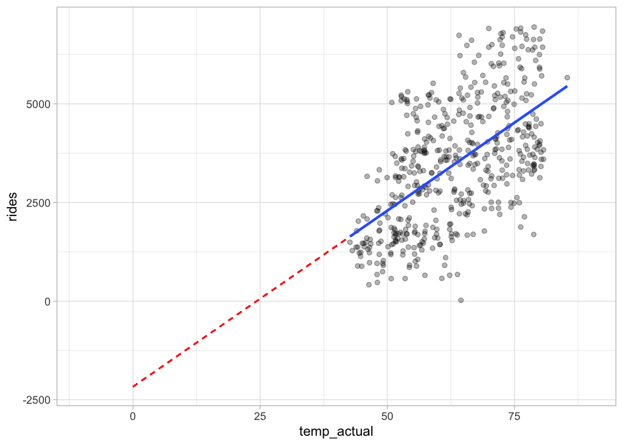

```r
ggplot(bikes,
       aes(x = temp_actual,
           y = rides)) +
  geom_jitter(alpha = .3) +
  geom_smooth(method = "lm",
              se = FALSE) +
  scale_x_continuous(limits = c(-10, 90)) +
  scale_y_continuous(limits = c(-2200, 7000)) +
  geom_segment(x = 0,
               y = -2169,
               xend = 42,
               yend = -2169 + 89.2*42,
               color = "red",
               linetype = "dashed")
```

OK let’s practice. What would the predicted ridership be for:

- a 60-degree day?
- a 72-degree day?
- an 80-degree day?

But how does this relate to the correlation coefficient? Let’s first get the correlation coefficient (and round it to two decimal places).

```r
get_correlation(rides ~ temp_actual,
                data = bikes) |>
  round(2)
```

```
   cor
1 0.58
```

What is this thing? The correlation coefficient is the expected change in standard deviations for one variable when the other variable changes by one standard deviation. How does this relate to the slope (89.2) we got from the regression?

Here’s how we write the regression slope with explicit units.

$$\frac{89.2\text{ rides}}{1 \text{ degree (F)}}$$

What if we had done the regression in Celsius instead? Let’s convert the temperature to Celsius.

```r
bikes <- bikes |>
  mutate(temp_celsius = (temp_actual-32)*(5/9))

model1c <- lm(rides ~ temp_celsius,
              data = bikes)
get_regression_table(model1c) |>
  select(term, estimate)
```

```
# A tibble: 2 × 2
  term         estimate
  <chr>           <dbl>
1 intercept        687.
2 temp_celsius     161.
```

So the formula now is:

$$\widehat{rides_i} = 687 + 161 \times Celsius_i$$

Being explicit about the units again, the slope coefficient is:

$$\frac{161\text{ rides}}{1 \text{ degree (C)}}$$

Does this change the correlation?

```r
get_correlation(rides ~ temp_celsius,
                data = bikes) |>
  round(2)
```

```
   cor
1 0.58
```

No it doesn’t!

What is the relationship between the correlation coefficient and the slope? We have to “get rid of the units”.

$$\frac{161\text{ rides}}{1 \text{ degree (C)}} \times \frac{\sigma_{\text{degrees (C)}}}{\sigma_{\text{rides}}}$$
Let’s do this using R like a calculator.

```r
(161 * (sd(bikes$temp_celsius) / sd(bikes$rides))) |>
  round(2)
```

```
[1] 0.58
```

Same correlation coefficient! We can say “when the temperature goes up by 1 standard deviation, we’d expect ridership to be .58 standard deviations higher.”

We can do the same thing with the original regression in degrees Fahrenheit.

```r
(89.2 * (sd(bikes$temp_actual) / sd(bikes$rides))) |>
  round(2)
```

```
[1] 0.58
```

Again, it’s the same, with exactly the same interpretation.

## Multiple regression

In real life, we rarely want to know just the relationship between one variable and another. In this case, we might want to be able to predict demand. For example, we might want to predict ridership so we could know when it’s a good time to maintain bikes (low demand) or a good time to have as many bikes available as possible (high demand).

Let’s look again at the data. What features do you think might predict demand for a bike sharing service?

```r
glimpse(bikes)
```

```
Rows: 500
Columns: 14
$ date         <date> 2011-01-01, 2011-01-03, 2011-01-04, 2011-01-05, 2011-01-…
$ season       <fct> winter, winter, winter, winter, winter, winter, winter, w…
$ year         <int> 2011, 2011, 2011, 2011, 2011, 2011, 2011, 2011, 2011, 201…
$ month        <fct> Jan, Jan, Jan, Jan, Jan, Jan, Jan, Jan, Jan, Jan, Jan, Ja…
$ day_of_week  <fct> Sat, Mon, Tue, Wed, Fri, Sat, Mon, Tue, Wed, Thu, Fri, Sa…
$ weekend      <lgl> TRUE, FALSE, FALSE, FALSE, FALSE, TRUE, FALSE, FALSE, FAL…
$ holiday      <fct> no, no, no, no, no, no, no, no, no, no, no, no, no, yes, …
$ temp_actual  <dbl> 57.39952, 46.49166, 46.76000, 48.74943, 46.50332, 44.1770…
$ temp_feel    <dbl> 64.72625, 49.04645, 51.09098, 52.63430, 50.79551, 46.6028…
$ humidity     <dbl> 80.5833, 43.7273, 59.0435, 43.6957, 49.8696, 53.5833, 48.…
$ windspeed    <dbl> 10.749882, 16.636703, 10.739832, 12.522300, 11.304642, 17…
$ weather_cat  <fct> categ2, categ1, categ1, categ1, categ2, categ2, categ1, c…
$ rides        <int> 654, 1229, 1454, 1518, 1362, 891, 1280, 1220, 1137, 1368,…
$ temp_celsius <dbl> 14.110847, 8.050924, 8.200000, 9.305237, 8.057402, 6.7650…
```

#### simple example

Let’s look at a pretty straightforward regression that builds on what we just did.

First of all, some functions don’t play well with logical variables (e.g., `weekend`) so we are going to make it a factor variable.

```r
bikes <- bikes |>
  mutate(weekend = as.factor(weekend))
glimpse(bikes)
```

```
Rows: 500
Columns: 14
$ date         <date> 2011-01-01, 2011-01-03, 2011-01-04, 2011-01-05, 2011-01-…
$ season       <fct> winter, winter, winter, winter, winter, winter, winter, w…
$ year         <int> 2011, 2011, 2011, 2011, 2011, 2011, 2011, 2011, 2011, 201…
$ month        <fct> Jan, Jan, Jan, Jan, Jan, Jan, Jan, Jan, Jan, Jan, Jan, Ja…
$ day_of_week  <fct> Sat, Mon, Tue, Wed, Fri, Sat, Mon, Tue, Wed, Thu, Fri, Sa…
$ weekend      <fct> TRUE, FALSE, FALSE, FALSE, FALSE, TRUE, FALSE, FALSE, FAL…
$ holiday      <fct> no, no, no, no, no, no, no, no, no, no, no, no, no, yes, …
$ temp_actual  <dbl> 57.39952, 46.49166, 46.76000, 48.74943, 46.50332, 44.1770…
$ temp_feel    <dbl> 64.72625, 49.04645, 51.09098, 52.63430, 50.79551, 46.6028…
$ humidity     <dbl> 80.5833, 43.7273, 59.0435, 43.6957, 49.8696, 53.5833, 48.…
$ windspeed    <dbl> 10.749882, 16.636703, 10.739832, 12.522300, 11.304642, 17…
$ weather_cat  <fct> categ2, categ1, categ1, categ1, categ2, categ2, categ1, c…
$ rides        <int> 654, 1229, 1454, 1518, 1362, 891, 1280, 1220, 1137, 1368,…
$ temp_celsius <dbl> 14.110847, 8.050924, 8.200000, 9.305237, 8.057402, 6.7650…
```

```r
model2 <- lm(rides ~ temp_celsius + weekend,
             data = bikes)
get_regression_table(model2) |>
  select(term, estimate)
```

```
# A tibble: 3 × 2
  term          estimate
  <chr>            <dbl>
1 intercept         942.
2 temp_celsius      157.
3 weekend: TRUE    -689.
```

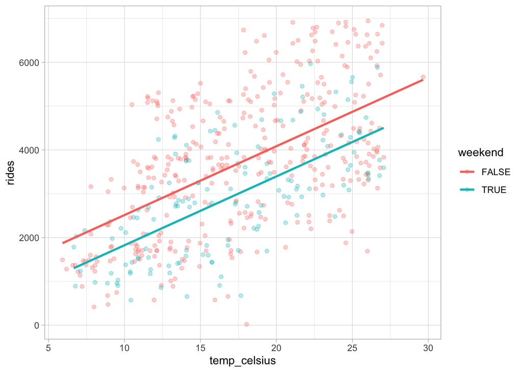

```r
ggplot(bikes,
       aes(x = temp_celsius,
           y = rides,
           group = weekend,
           color = weekend)) +
  geom_jitter(alpha = .3) +
  geom_parallel_slopes(se = FALSE)
```

This model assumes parallel slopes—that temperature has the same effect regardless of whether it’s a weekday or weekend. But is that true? Let’s look.

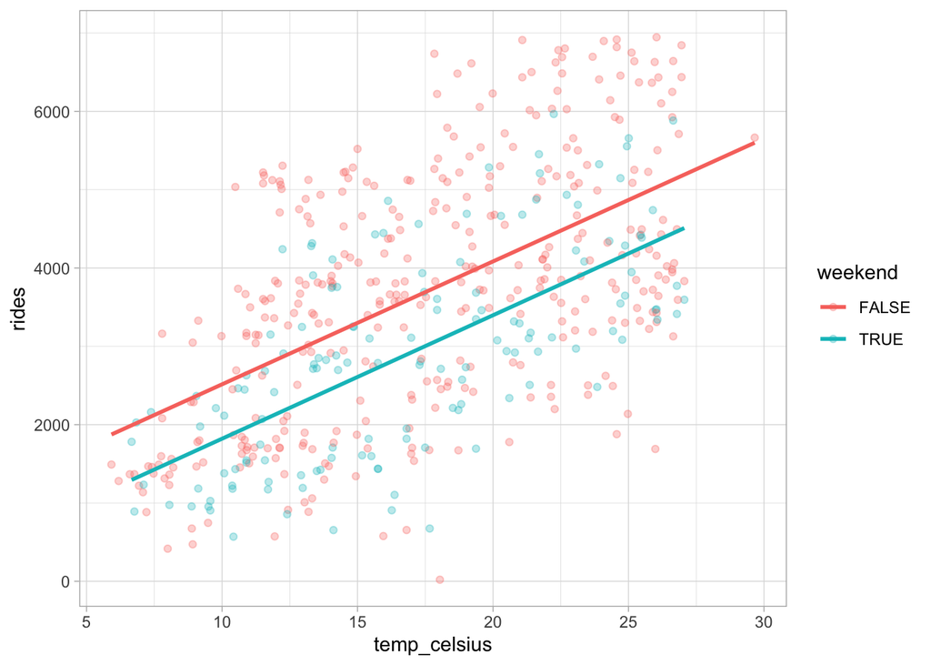

```r
ggplot(bikes,
       aes(x = temp_celsius,
           y = rides,
           group = weekend,
           color = weekend)) +
  geom_jitter(alpha = .3) +
  geom_smooth(method = "lm",
              se = FALSE)
```

```r
model3 <- lm(rides ~ temp_celsius * weekend,
             data = bikes)
get_regression_table(model3) |>
  select(term, estimate)
```

```
# A tibble: 4 × 2
  term                     estimate
  <chr>                       <dbl>
1 intercept                  946.
2 temp_celsius               157.
3 weekend: TRUE             -702.
4 temp_celsius:weekendTRUE     0.74
```

Look at the interaction coefficient. How different is the slope between weekdays and weekends?

#### more complex

We can have multiple continuous predictors.

```r
model4 <- lm(rides ~ temp_celsius + windspeed + weekend,
             data = bikes)
get_regression_table(model4) |>
  select(term, estimate)
```

```
# A tibble: 4 × 2
  term          estimate
  <chr>            <dbl>
1 intercept       1529.
2 temp_celsius     153.
3 windspeed        -39.4
4 weekend: TRUE   -696.
```

We can get predictions.

```r
library(ggeffects)
predictions <- ggpredict(model4,
                         terms = "temp_celsius",
                         ci_level = NA) # don't think about confidence intervals yet (soon!)
predictions
```

```
# Predicted values of rides

temp_celsius | Predicted
------------------------
           5 |   1780.52
          10 |   2545.54
          15 |   3310.55
          20 |   4075.57
          25 |   4840.59
          30 |   5605.60

Adjusted for:
* windspeed = 13.02
*   weekend = FALSE
```

Note that these predictions hold windspeed constant at its mean (13.02) and weekend constant at its most common value (or mode), which is a weekday.

We can plot these adjusted predictions.

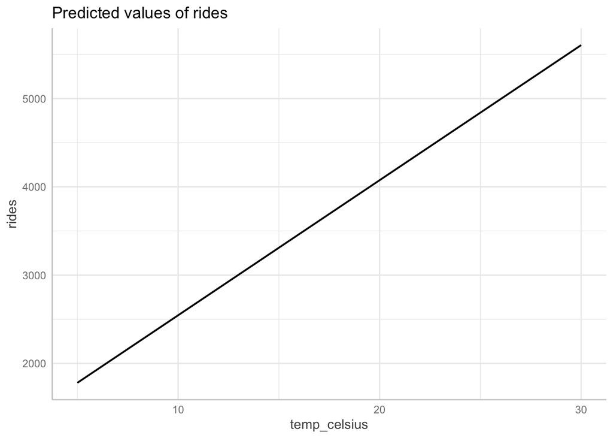

```r
plot(predictions)
```

#### happiness data

Why do we put multiple predictors in a model? Let’s look at the example of life satisfaction.

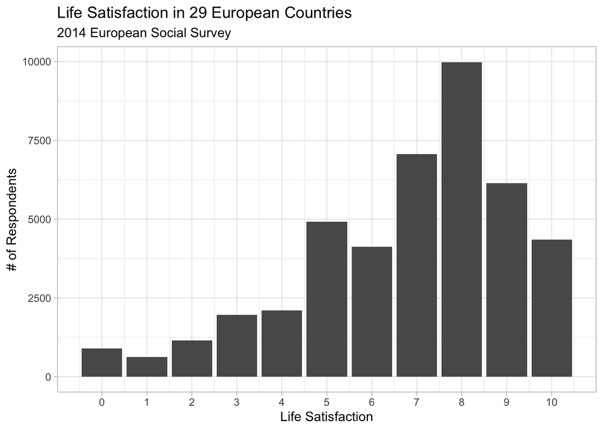

```r
library(here)
happy <- haven::read_dta(here("data", "ess-stflife.dta"))

ggplot(happy,
       aes(x = stflife)) +
  geom_bar() +
  scale_x_continuous(breaks = 0:10) +
  labs(x = "Life Satisfaction",
       y = "# of Respondents",
       title = "Life Satisfaction in 29 European Countries",
       subtitle = "2014 European Social Survey")
```

What’s the relationship between happiness and education?

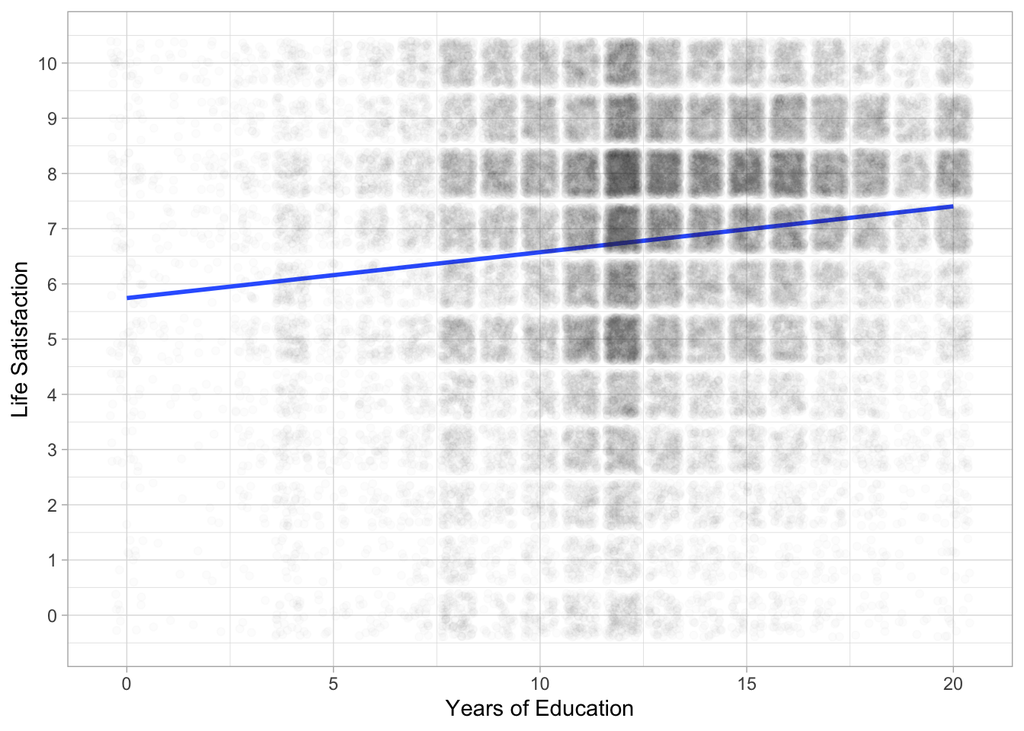

```r
ggplot(happy,
       aes(x = eduyrs,
           y = stflife)) +
  geom_smooth(method = "lm",
              se = FALSE) +
  geom_jitter(alpha = .01) +
  scale_y_continuous(breaks = 0:10) +
  labs(y = "Life Satisfaction",
       x = "Years of Education")
```

```r
happy1 <- lm(stflife ~ eduyrs,
             data = happy)
get_regression_table(happy1) |>
  select(term, estimate)
```

```
# A tibble: 2 × 2
  term      estimate
  <chr>        <dbl>
1 intercept    5.74
2 eduyrs       0.083
```

How much happier are those with zero education expected to be compared to people with 20 years of education?

Now let’s add income and health. *Income* is measured in **deciles** (like percentiles, but coarser) from 1 to 10 in each country. *Health* is self-reported health measured on a scale from 1 (poor) to 5 (excellent).

```r
happy2 <- lm(stflife ~ eduyrs + inc + health,
             data = happy)
get_regression_table(happy2) |>
  select(term, estimate)
```

```
# A tibble: 4 × 2
  term      estimate
  <chr>        <dbl>
1 intercept    3.26
2 eduyrs      -0.003
3 inc          0.154
4 health       0.742
```

Now what is the 0 vs. 20 year education difference? Why is this different from before?

#### functional form

Is the relationship between income and happiness really a straight line?

```r
happy3 <- lm(stflife ~ eduyrs + factor(inc) + health,
             data = happy)
get_regression_table(happy3) |>
  select(term, estimate)
```

```
# A tibble: 12 × 2
   term            estimate
   <chr>              <dbl>
 1 intercept          3.17
 2 eduyrs            -0.003
 3 factor(inc): 2     0.423
 4 factor(inc): 3     0.724
 5 factor(inc): 4     0.826
 6 factor(inc): 5     0.89
 7 factor(inc): 6     1.11
 8 factor(inc): 7     1.24
 9 factor(inc): 8     1.28
10 factor(inc): 9     1.46
11 factor(inc): 10    1.53
12 health             0.739
```

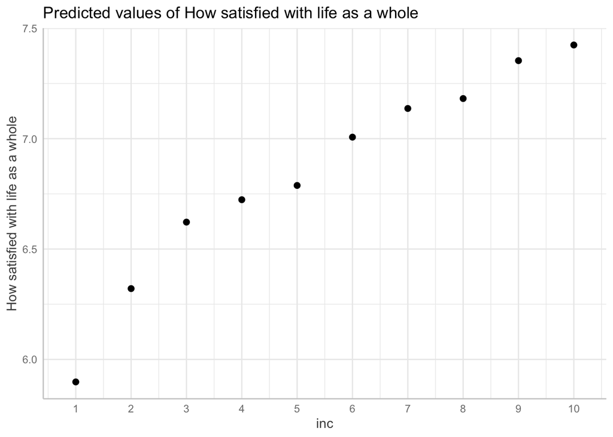

```r
ggpredict(happy3,
          terms = "inc",
          ci_level = NA) |>
  plot() +
  scale_x_continuous(breaks = 1:10)
```

The plot shows us the differences as we move up by deciles—since we `factor(inc)`, everything is in reference to the first decile.

Let’s look at age.

```r
happy4 <- lm(stflife ~ eduyrs + inc + health + age,
             data = happy)
get_regression_table(happy4) |>
  select(term, estimate)
```

```
# A tibble: 5 × 2
  term      estimate
  <chr>        <dbl>
1 intercept    1.63
2 eduyrs       0.014
3 inc          0.159
4 health       0.859
5 age          0.019
```

What is the effect of each additional year?

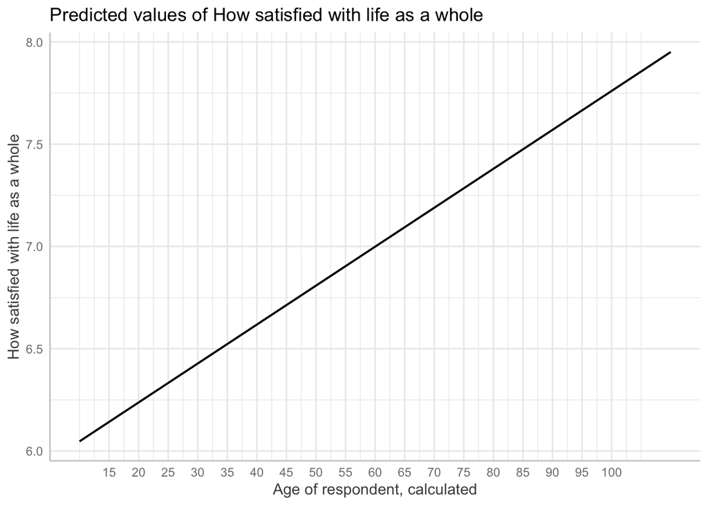

```r
ggpredict(happy4,
          terms = "age",
          ci_level = NA) |>
  plot() +
  scale_x_continuous(breaks = seq(from = 15,
                                  to = 100,
                                  by = 5))
```

But is a straight line really best? We can ask for a parabola instead.

```r
happy5 <- lm(stflife ~ eduyrs + inc + health + age + I(age^2), # I(age^2) adds the quadratic term
             data = happy)
get_regression_table(happy5) |>
  select(term, estimate)
```

```
# A tibble: 6 × 2
  term      estimate
  <chr>        <dbl>
1 intercept    3.28
2 eduyrs       0.022
3 inc          0.172
4 health       0.85
5 age         -0.062
6 I(age^2)     0.001
```

```r
AIC(happy5)
```

```
[1] 189372
```

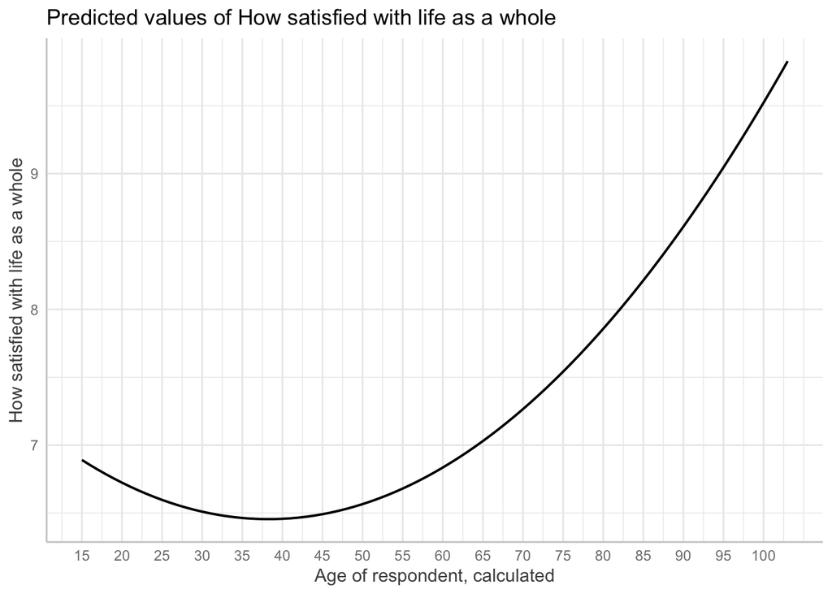

```r
ggpredict(happy5,
          terms = "age", #ggpredict is smart, so it grabs both of the age terms without specifying
          ci_level = NA) |>
  plot() +
  scale_x_continuous(breaks = seq(from = 15,
                                  to = 100,
                                  by = 5))
```

With differential mortality, there’s a chance that other factors such as health might affect the happiness. There aren’t a ton of people who make it past 85, so you have to be careful taking the model’s word as gospel.

```r
happy6 <- lm(stflife ~ eduyrs + inc + health + age + I(age^3), # I(age^3) adds the cubic term
             data = happy)
get_regression_table(happy6) |>
  select(term, estimate)
```

```
# A tibble: 6 × 2
  term      estimate
  <chr>        <dbl>
1 intercept    2.68
2 eduyrs       0.021
3 inc          0.171
4 health       0.849
5 age         -0.021
6 I(age^3)     0
```

```r
AIC(happy6)
```

```
[1] 189425.7
```

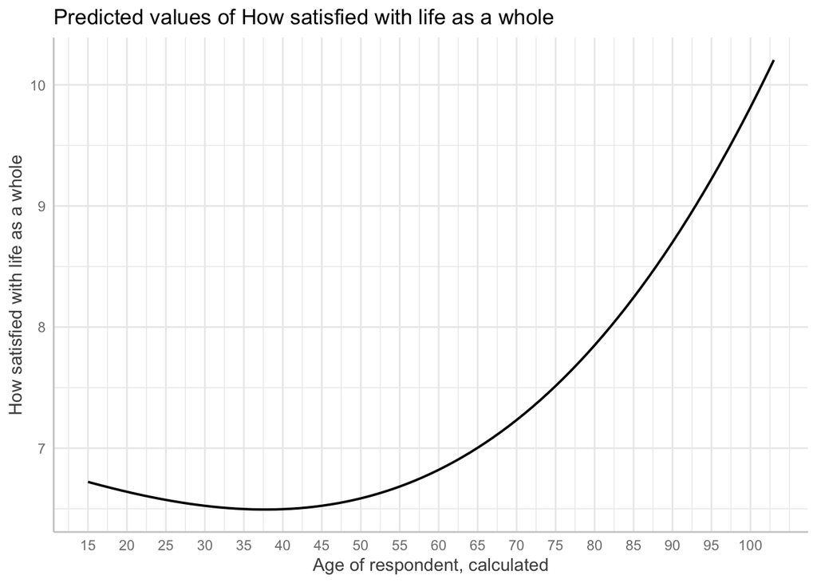

```r
ggpredict(happy6,
          terms = "age", #ggpredict is smart, so it grabs both of the age terms without specifying
          ci_level = NA) |>
  plot() +
  scale_x_continuous(breaks = seq(from = 15,
                                  to = 100,
                                  by = 5))
```

```r
happy7 <- lm(stflife ~ eduyrs + inc + health + age + I(age^0.5), # I(age^0.5) adds the sqrt term
             data = happy)
get_regression_table(happy7) |>
  select(term, estimate)
```

```
# A tibble: 6 × 2
  term       estimate
  <chr>         <dbl>
1 intercept     8.55
2 eduyrs        0.023
3 inc           0.173
4 health        0.851
5 age           0.176
6 I(age^0.5)   -2.15
```

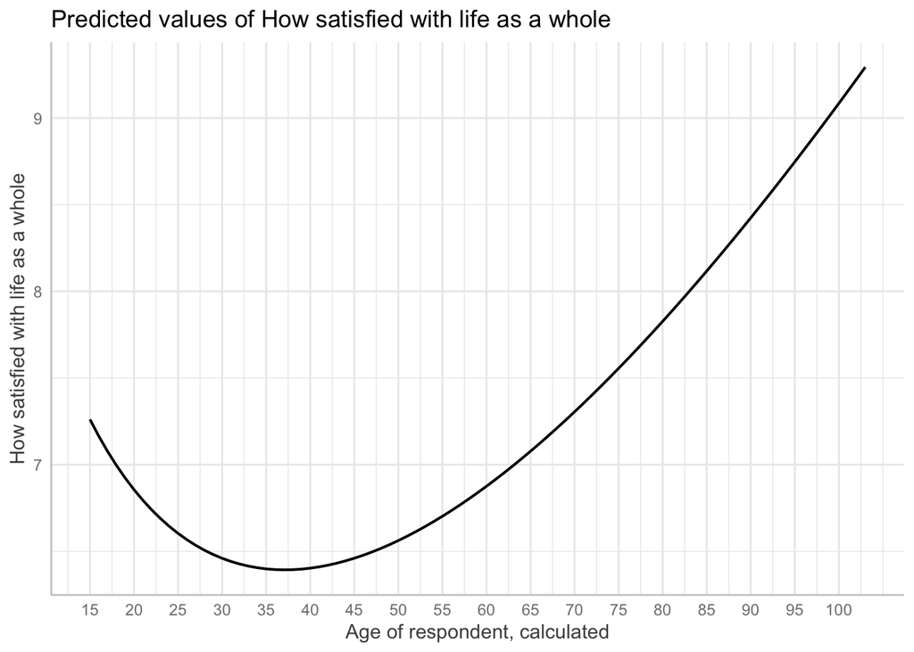

```r
ggpredict(happy7,
          terms = "age", #ggpredict is smart, so it grabs both of the age terms without specifying
          ci_level = NA) |>
  plot() +
  scale_x_continuous(breaks = seq(from = 15,
                                  to = 100,
                                  by = 5))
```

```r
AIC(happy7)
```

```
[1] 189323.9
```

Square root does the best!